# TxDot Usability Social Media Analysis

Jacob Copple

November 17, 2018

### R Markdown

This markdown file was created and obtained through a class project agreement with the Texas Department of Transportation. All information presented was gained by permission from Communications Director [Beth Hallmark](https://www.txdot.gov/inside-txdot/division/communications/director.html).

Please email jgcopple@utexas.edu with any questions or requests.

### Packages

```r
library(dplyr)
```

```r
library(ggplot2)
library(gridExtra)
library(tidytext)
library(wordcloud2)
library(lubridate)
library(kableExtra)
library(formattable)
library(forecast)
library(wordcloud2)
library(tidyr)
library(circlize)
library(ggrepel)
library(igraph)
library(ggraph)
library(widyr)
```

### Data file import

Change this file to the file path on your computer. I’ll provide this to the class in Canvas.

```r
fb = read.csv("C:\\Users\\Jacob\\Google Drive\\Usability\\facebook_engagement_2017-10-01_to_2018-10-24_created_on_20181117T2209Z_facebook_inbound_messages.csv", stringsAsFactors = FALSE)
```

### Clean and Filter Wanted Columns

```r
nlp_fb <- fb %>%
  select(date = Date..GMT.,
         message = Post.Message,
         post_permalink = Post.Permalink,
         type = Type)
```

### Turn Dates from Character Strings to Numeric/ Create new column of months

```r
nlp_fb$date <- as.Date(as.POSIXct(nlp_fb$date, 'GMT'))

nlp_fb$month <- month(as.POSIXlt(nlp_fb$date, format = "%Y-%m-%d"))
```

### Function and command to expand contractions

```r
fix.contractions <- function(doc) {
  # "won't" is a special case as it does not expand to "wo not"
  doc <- gsub("won't", "will not", doc)
  doc <- gsub("can't", "can not", doc)
  doc <- gsub("n't", " not", doc)
  doc <- gsub("'ll", " will", doc)
  doc <- gsub("'re", " are", doc)
  doc <- gsub("'ve", " have", doc)
  doc <- gsub("'m", " am", doc)
  doc <- gsub("'d", " would", doc)
  # 's could be 'is' or could be possessive: it has no expansion
  doc <- gsub("'s", "", doc)
  return(doc)
}

nlp_fb$message <- sapply(nlp_fb$message, fix.contractions)
```

### Function and command to remove URLs

```r
removeSpecialChars <- function(x) {
  x <- gsub("(f|ht)(tp)(s?)(://)(\\S*)", "", x)
  x <- gsub(" #\\S*", "", x)
  x <- gsub("@[a-z,A-Z]*", "", x)
  x <- gsub("[^[:alnum:][:space:]'-]", "", x)
  x <- gsub("[^\x01-\x7F]", "", x)
  x <- gsub("[[:digit:]]+", "", x)
  return(x)
}

nlp_fb$message <- sapply(nlp_fb$message, removeSpecialChars)
```

### Lower case characters

```r
nlp_fb$message <- sapply(nlp_fb$message, tolower)
```

### Plot Themed Colors

```r
my_colors <- c("#E69F00", "#56B4E9", "#009E73", "#CC79A7", "#D55E00")
theme_nlp <- function()
{
  theme(plot.title = element_text(hjust = 0.5),
        #axis.text.x = element_blank(),
        #axis.ticks = element_blank(),
        panel.grid.major = element_blank(),
        panel.grid.minor = element_blank(),
        legend.position = "none")
}
```

### Undesirable Words based on sample and previous research

```r
undesirable_words <- c("texas", "department", "transportation","private message", "theres", "fe0f", "yeah", "alright", "wanna", "gonna", "whoa", "gotta")
```

### Tokenize, remove stopwords, undesirable words, and words less than three characters long

```r
fb_tidy <- nlp_fb %>%
  unnest_tokens(word, message) %>%
  anti_join(stop_words) %>%
  distinct() %>%
  filter(!word %in% undesirable_words) %>%
  filter(nchar(word) > 3)
# class(tw_words_filtered)
# dim(tw_words_filtered)

full_word_count <- nlp_fb %>%
  unnest_tokens(word, message) %>%
  group_by(month) %>%
  summarise(num_words = n()) %>%
  arrange(desc(num_words))
```

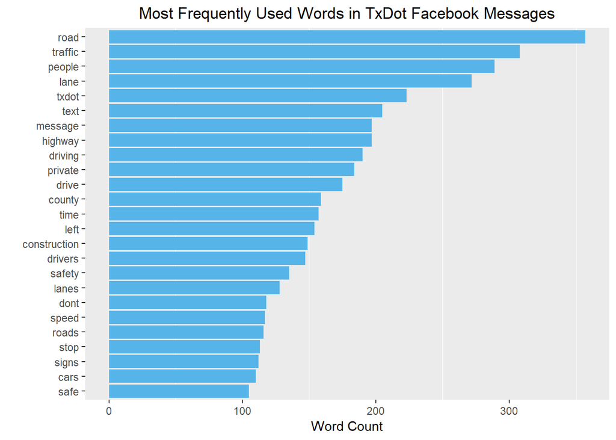

```r
fb_tidy %>%
    count(word, sort = TRUE) %>%
    top_n(25) %>%
    ungroup() %>%
    mutate(word = reorder(word, n)) %>%
    ggplot() +
    geom_col(aes(word, n), fill = my_colors[2]) +
    theme(legend.position = "none",
          plot.title = element_text(hjust = 0.5),
          panel.grid.major = element_blank()) +
    xlab("") +
    ylab("Word Count") +
    ggtitle("Most Frequently Used Words in TxDot Facebook Messages") +
    coord_flip()
```

### Other Descriptives and Frequencies for Tweet Data

```r
fb_word_count <- fb_tidy %>%
  count(word, sort = TRUE)

popular_words <- fb_tidy %>%
  group_by(month) %>%
  count(word, month, sort = TRUE) %>%
  slice(seq_len(8)) %>%
  ungroup() %>%
  arrange(month,n) %>%
  mutate(row = row_number())

frequency <- fb_tidy %>%
  group_by(month) %>%
  count (word, sort = TRUE) %>%
  left_join(fb_tidy %>%
              group_by(month) %>%
              summarise(total = n())) %>%
  mutate(freq = n/total)
```

### Word Cloud with TxDot Tweets

This will work fine with the appropriate package listed above, but for somereason the transfer from R markdown file to html file doesn’t work. Feel free to use if you’d like.

```r
# fb_tidy %>%
#   anti_join(stop_words) %>%
#   count(word) %>%
#   with(wordcloud(word,n, max.words= 125))
```

### Creating Bing and NRC sentiment data tables

```r
fb_nrc <- fb_tidy %>%
  inner_join(get_sentiments("nrc"))
fb_bing <- fb_tidy %>%
  inner_join(get_sentiments("bing")) %>%
  count(word, sentiment, month, date) %>%
  spread(sentiment, n, fill=0) %>%
  mutate(sentiment = positive - negative)
# fb_words_filtered %>%
# rename("hoot_sentiment" = "sentiment")
```

## Bing Sentiment Analysis

### Bing sentiment word counts

```r
bing_word_counts <- fb_tidy %>%
  inner_join(get_sentiments("bing")) %>%
  count(word, sentiment, sort = TRUE) %>%
  ungroup()
```

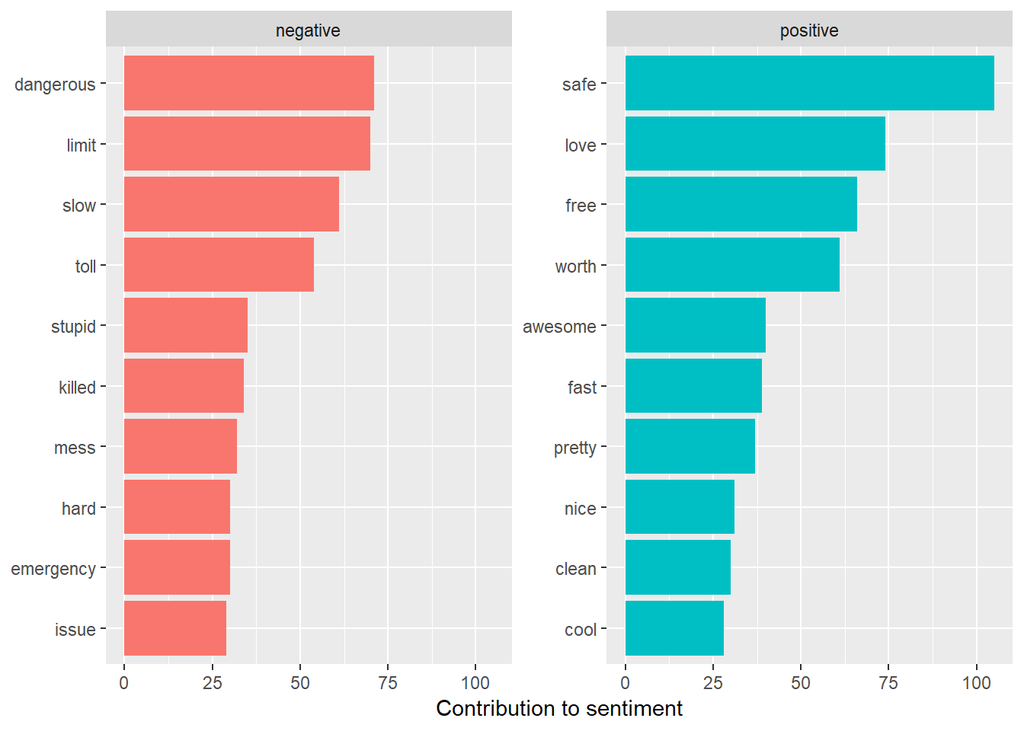

```r
bing_word_counts %>%
  group_by(sentiment) %>%
  top_n(10) %>%
  ungroup() %>%
  mutate(word = reorder(word, n)) %>%
  ggplot(aes(word, n, fill = sentiment)) +
  geom_col(show.legend = FALSE) +
  facet_wrap(~sentiment, scales = "free_y") +
  labs(y = "Contribution to sentiment",
       x = NULL) +
  coord_flip()
```

### Bing Sentiment Polarity

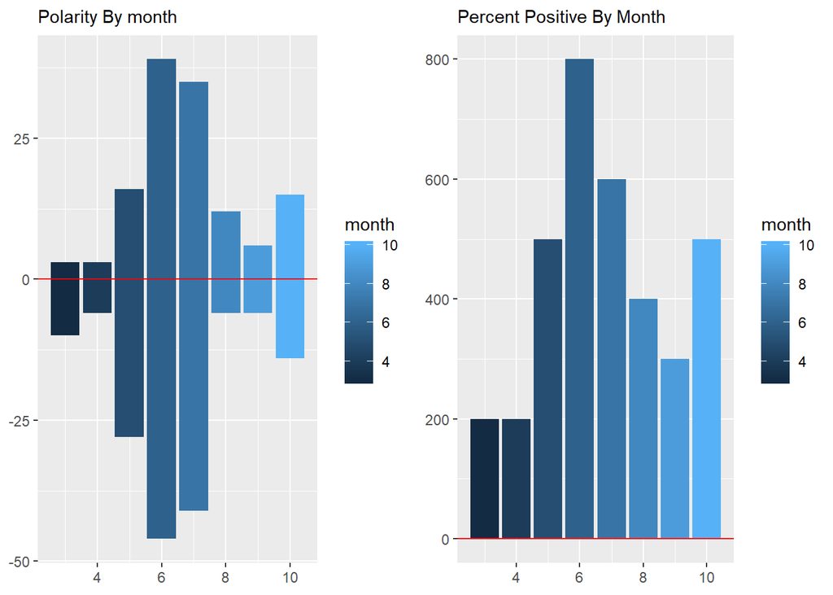

```r
fb_polarity_chart <- fb_bing %>%
  count(sentiment, month, positive, negative) %>%
  spread(sentiment, n, fill = 0) %>%
  mutate(polarity = positive - negative,
  percent_positive = positive / (positive + negative) * 100)

plot1 <- fb_polarity_chart %>%
  ggplot( aes(month, polarity, fill = month)) +
  geom_col() +
  geom_hline(yintercept = 0, color = "red") +
  theme(plot.title = element_text(size = 11)) +
  xlab(NULL) + ylab(NULL) +
  ggtitle("Polarity By month")

plot2 <- fb_polarity_chart %>%
  ggplot( aes(month, percent_positive, fill = month)) +
  geom_col() +
  geom_hline(yintercept = 0, color = "red") +
  theme(plot.title = element_text(size = 11)) +
  xlab(NULL) + ylab(NULL) +
  ggtitle("Percent Positive By Month")

grid.arrange(plot1, plot2, ncol = 2)
```

### Bing Polarity Overtime

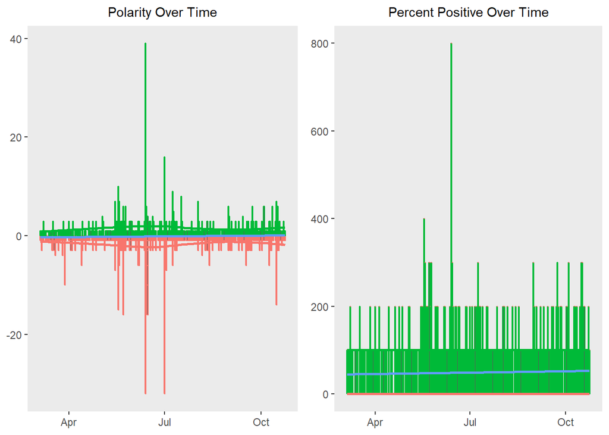

```r
fb_polarity_month <- fb_bing %>%
  count(sentiment, date, positive, negative) %>%
  spread(sentiment, n, fill = 0) %>%
  mutate(polarity = positive - negative,
         percent_positive = positive / (positive + negative) * 100)

polarity_over_time <- fb_polarity_month %>%
  ggplot(aes(date, polarity, color = ifelse(polarity >= 0,my_colors[5],my_colors[4]))) +
  geom_col() +
  geom_smooth(method = "loess", se = FALSE) +
  geom_smooth(method = "lm", se = FALSE, aes(color = my_colors[1])) +
  theme_nlp() + theme(plot.title = element_text(size = 11)) +
  xlab(NULL) + ylab(NULL) +
  ggtitle("Polarity Over Time")

relative_polarity_over_time <- fb_polarity_month %>%
  ggplot(aes(date, percent_positive , color = ifelse(polarity >= 0,my_colors[5],my_colors[4]))) +
  geom_col() +
  geom_smooth(method = "loess", se = FALSE) +
  geom_smooth(method = "lm", se = FALSE, aes(color = my_colors[1])) +
  theme_nlp() + theme(plot.title = element_text(size = 11)) +
  xlab(NULL) + ylab(NULL) +
  ggtitle("Percent Positive Over Time")

grid.arrange(polarity_over_time, relative_polarity_over_time, ncol = 2)
```

## NRC Sentiment Analysis

### Circle Chart for relationship of Mood by Month

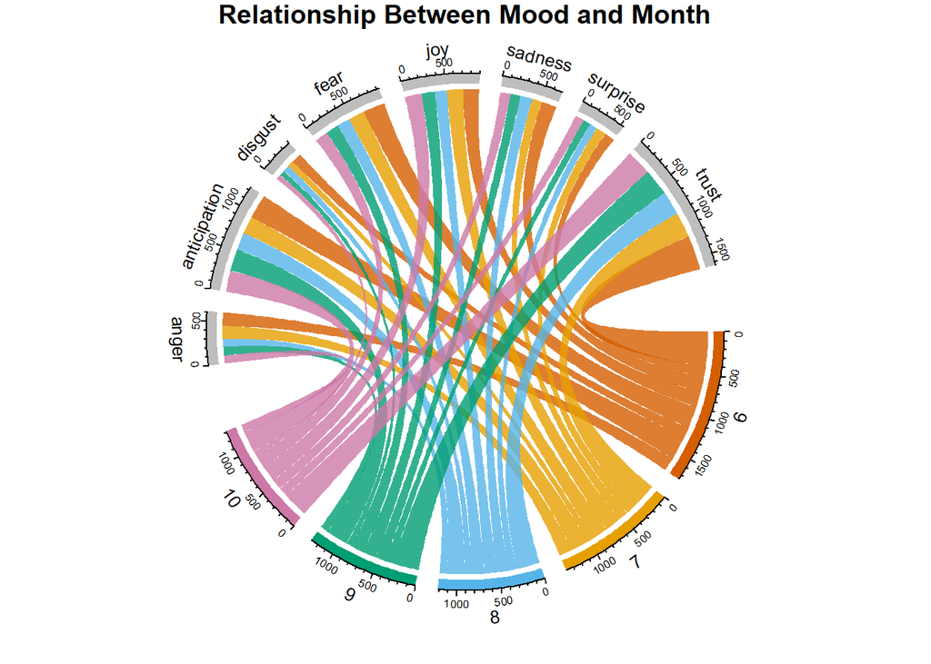

```r
grid.col = c("7" = my_colors[1], "8" = my_colors[2], "9" = my_colors[3], "10" = my_colors[4],
             "6" = my_colors[5], "anger" = "grey", "anticipation" = "grey", "disgust" = "grey",
             "fear" = "grey", "joy" = "grey", "sadness" = "grey", "surprise" = "grey", "trust" = "grey")
key_months <-c("2", "3", "4", "5")

month_mood <-  fb_nrc %>%
  filter(!month %in% key_months & !sentiment %in% c("positive", "negative")) %>%
  count(sentiment, month) %>%
  group_by(month, sentiment) %>%
  summarise(sentiment_sum = sum(n)) %>%
  ungroup()

circos.clear()
#Set the gap size
circos.par(gap.after = c(rep(5, length(unique(month_mood[[1]])) - 1), 15,
                         rep(5, length(unique(month_mood[[2]])) - 1), 15))
chordDiagram(month_mood, grid.col = grid.col, transparency = .2)
title("Relationship Between Mood and Month")
```

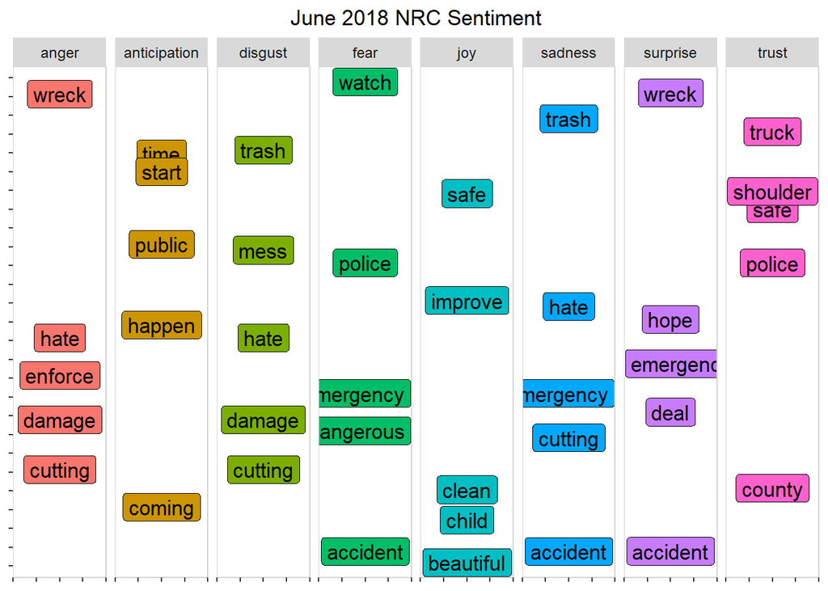

```r
plot_words_june <- fb_nrc %>%
  filter(month == 6 & !sentiment %in% c("positive", "negative")) %>%
  group_by(sentiment) %>%
  count(sentiment, word, sort = TRUE) %>%
  arrange(desc(n)) %>%
  slice(seq_len(5)) %>% #consider top_n() from dplyr also
  ungroup()

plot_words_june %>%
  #Set `y = 1` to just plot one variable and use word as the label
  ggplot(aes(word, 1, label = word, fill = sentiment )) +
  #You want the words, not the points
  geom_point(color = "transparent") +
  #Make sure the labels don't overlap
  geom_label_repel(force = 1,nudge_y = 0,
                   direction = "y",
                   box.padding = 0.04,
                   segment.color = "transparent",
                   size = 4.5) +
  facet_grid(~sentiment) +
  theme_nlp() +
  theme(axis.text.y = element_blank(), axis.text.x = element_blank(),
        axis.title.x = element_text(size = 6),
        panel.grid = element_blank(), panel.background = element_blank(),
        panel.border = element_rect("lightgray", fill = NA),
        strip.text.x = element_text(size = 9)) +
  xlab(NULL) + ylab(NULL) +
  ggtitle("June 2018 NRC Sentiment") +
  coord_flip()
```

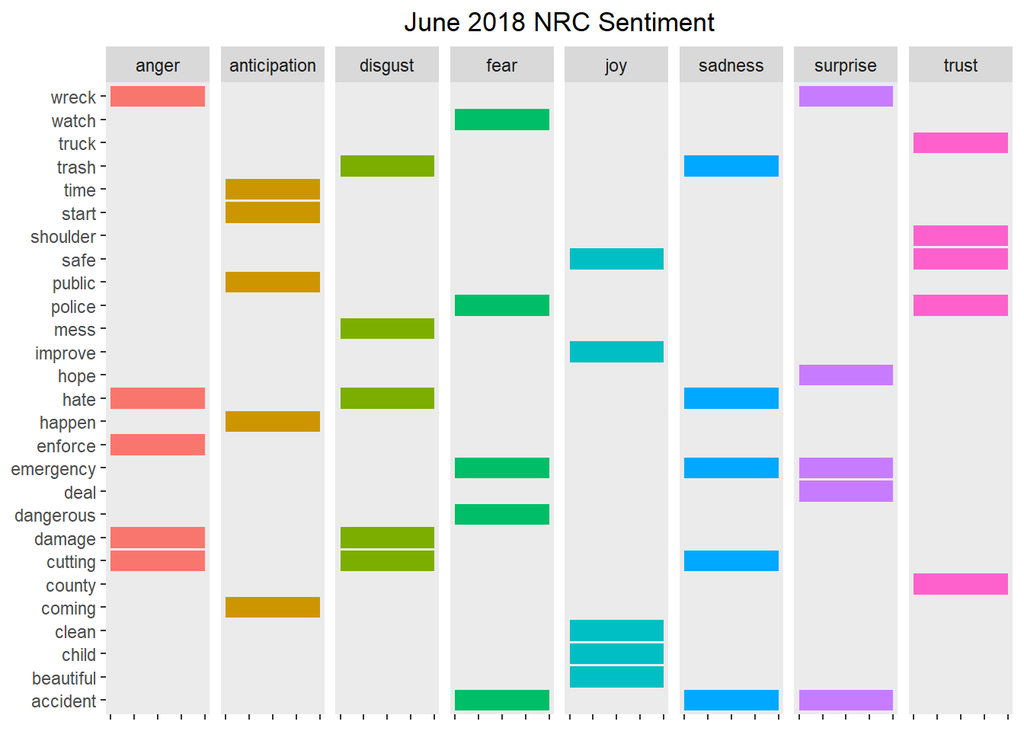

```r
plot_words_june %>%
  ggplot(aes(x = word, fill = sentiment)) +
  facet_grid(~sentiment) +
  geom_bar() + #Create a bar for each word per sentiment
  theme_nlp() +
  theme(panel.grid.major.x = element_blank(),
        axis.text.x = element_blank()) + #Place the words on the y-axis
  xlab(NULL) + ylab(NULL) +
  ggtitle("June 2018 NRC Sentiment") +
  coord_flip()
```

### Pairwise Comparisons and Correlations

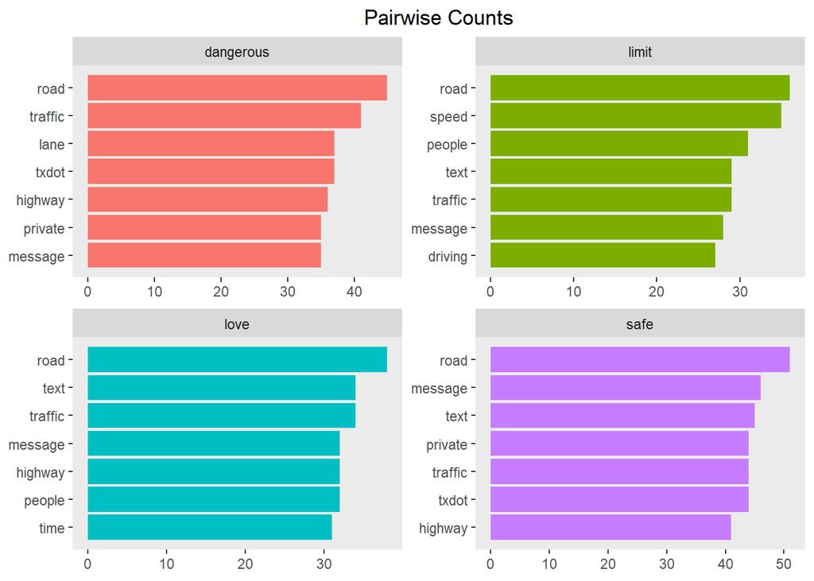

```r
pwc <- fb_tidy %>%
  filter(n() >= 20) %>%
  pairwise_count(word, date, sort = TRUE) %>%
  filter(item1 %in% c("love", "safe", "limit", "dangerous")) %>%
  group_by(item1) %>%
  slice(seq_len(7)) %>%
  ungroup() %>%
  mutate(row = -row_number())

pwc %>%
  ggplot(aes(row, n, fill = item1)) +
  geom_bar(stat = "identity", show.legend = FALSE) +
  facet_wrap(~item1, scales = "free") +
  scale_x_continuous(  #This handles replacement of row
    breaks = pwc$row, #Notice need to reuse data frame
    labels = pwc$item2) +
  theme_nlp() + theme(panel.grid.major.x = element_blank()) +
  xlab(NULL) + ylab(NULL) +
  ggtitle("Pairwise Counts") +
  coord_flip()
```

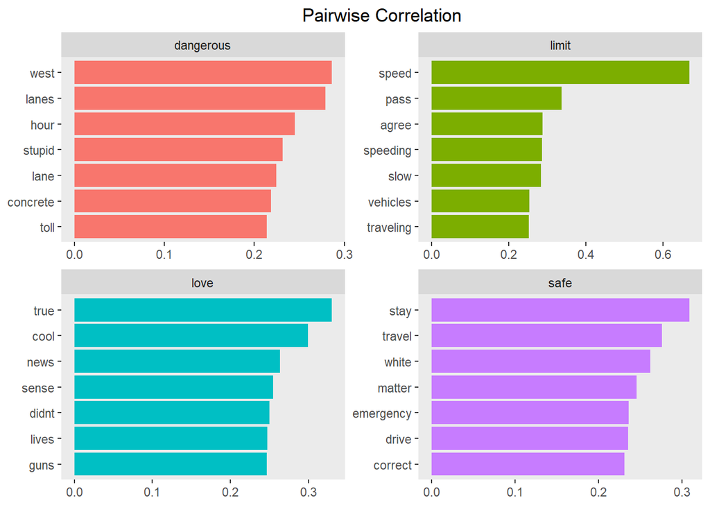

```r
fb_tidy %>%
  group_by(word) %>%
  filter(n() >= 20) %>%
  pairwise_cor(word, date, sort = TRUE) %>%
  filter(item1 %in% c("love", "safe", "limit", "dangerous")) %>%
  group_by(item1) %>%
  top_n(7) %>%
  ungroup() %>%
  mutate(item2 = reorder(item2, correlation)) %>%
  ggplot(aes(item2, correlation, fill = item1)) +
  geom_bar(stat = 'identity', show.legend = FALSE) +
  facet_wrap(~item1, scales = 'free') +
  theme_nlp() + theme(panel.grid.major.x = element_blank()) +
  xlab(NULL) + ylab(NULL) +
  ggtitle("Pairwise Correlation") +
  coord_flip()
```

## Bigrams Analysis

Previous analysis isolated single words. Bigrams introduce two word combinations

### Bigrams by Month

```r
fb_bigrams <- nlp_fb %>%
  unnest_tokens(bigram, message, token = "ngrams", n = 2)

bigrams_separated <- fb_bigrams %>%
  separate(bigram, c("word1", "word2"), sep = " ")

bigrams_filtered <- bigrams_separated %>%
  filter(!word1 %in% stop_words$word) %>%
  filter(!word2 %in% stop_words$word) %>%
  filter(!word1 %in% undesirable_words) %>%
  filter(!word2 %in% undesirable_words)

bigram_month <- bigrams_filtered %>%
  filter(word1 != word2) %>%
  filter(month != "NA") %>%
  unite(bigram, word1, word2, sep = " ") %>%
  inner_join(nlp_fb) %>%
  count(bigram, month, sort = TRUE) %>%
  group_by(month) %>%
  slice(seq_len(7)) %>%
  ungroup() %>%
  arrange(month, n) %>%
  mutate(row = row_number())
```

### Bigram X Month graphs

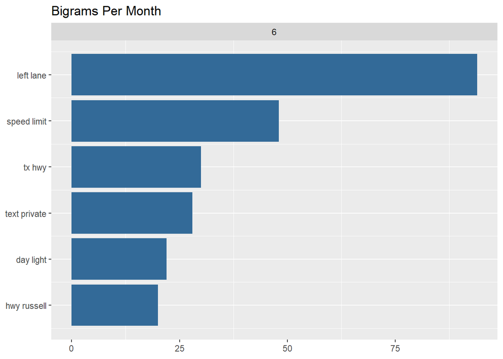

```r
bigram_month %>%
  filter(month == "6", bigram != "private message") %>%
  ggplot(aes(row, n, fill = month)) +
  geom_col(show.legend = FALSE) +
  facet_wrap(~month, scales = "free_y") +
  xlab(NULL) + ylab(NULL) +
  scale_x_continuous(
    breaks = bigram_month$row,
    labels = bigram_month$bigram) +
  theme(panel.grid.major.x = element_blank()) +
  ggtitle("Bigrams Per Month") +
  coord_flip()
```

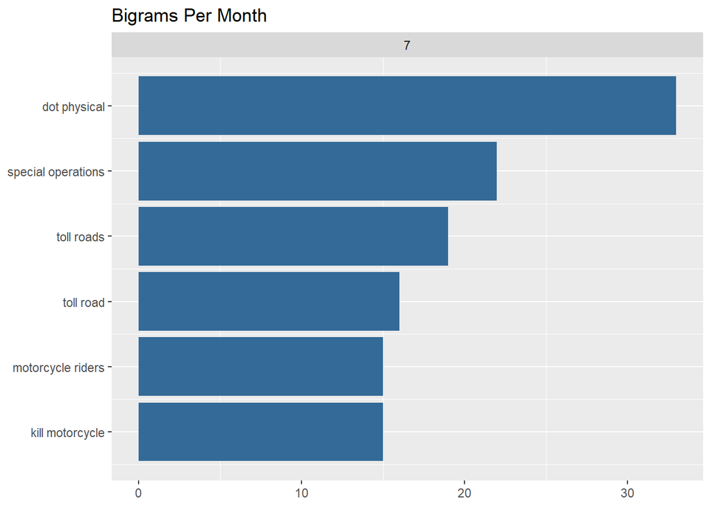

```r
bigram_month %>%
  filter(month == "7", bigram != "private message") %>%
  ggplot(aes(row, n, fill = month)) +
  geom_col(show.legend = FALSE) +
  facet_wrap(~month, scales = "free_y") +
  xlab(NULL) + ylab(NULL) +
  scale_x_continuous(
    breaks = bigram_month$row,
    labels = bigram_month$bigram) +
  theme(panel.grid.major.x = element_blank()) +
  ggtitle("Bigrams Per Month") +
  coord_flip()
```

### Negation Analysis to inlcude two word phrases with “Not” “No” “Never” “without”

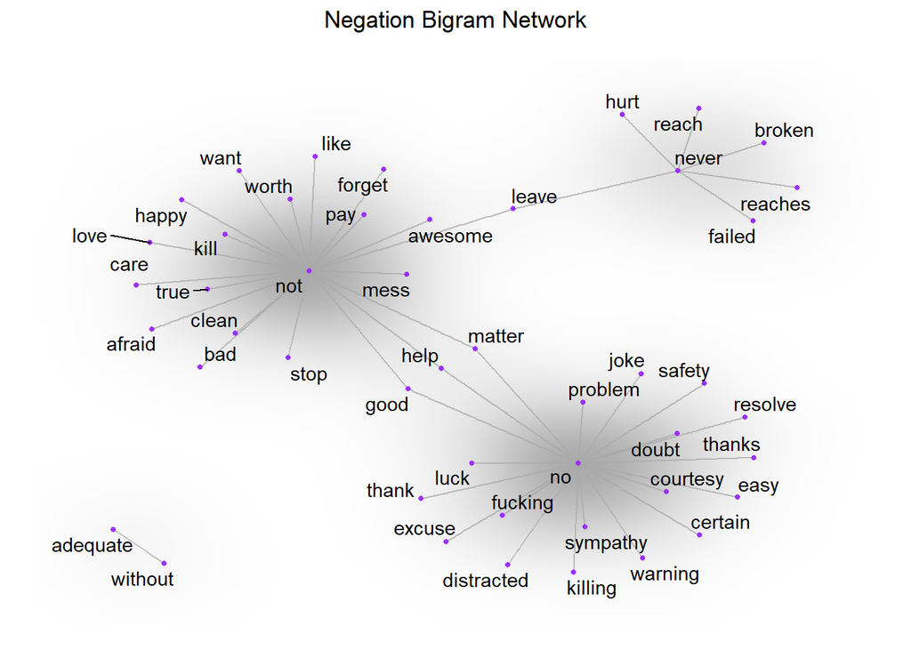

```r
AFINN <- get_sentiments("afinn")

negation_words <- c("not", "no", "never", "without")

negation_bigrams <- bigrams_separated %>%
  filter(word1 %in% negation_words) %>%
  inner_join(AFINN, by = c(word2 = "word")) %>%
  count(word1, word2, score, sort = TRUE) %>%
  mutate(contribution = n * score) %>%
  arrange(desc(abs(contribution))) %>%
  group_by(word1) %>%
  slice(seq_len(20)) %>%
  arrange(word1,desc(contribution)) %>%
  ungroup()

bigram_graph <- negation_bigrams %>%
  graph_from_data_frame() #From `igraph`

set.seed(123)

a <- grid::arrow(type = "closed", length = unit(.15, "inches"))

ggraph(bigram_graph, layout = "fr") +
  geom_edge_link(alpha = .25) +
  geom_edge_density(aes(fill = score)) +
  geom_node_point(color = "purple1", size = 1) +
  geom_node_text(aes(label = name),  repel = TRUE) +
  theme_void() + theme(legend.position = "none",
                       plot.title = element_text(hjust = 0.5)) +
  ggtitle("Negation Bigram Network")
```

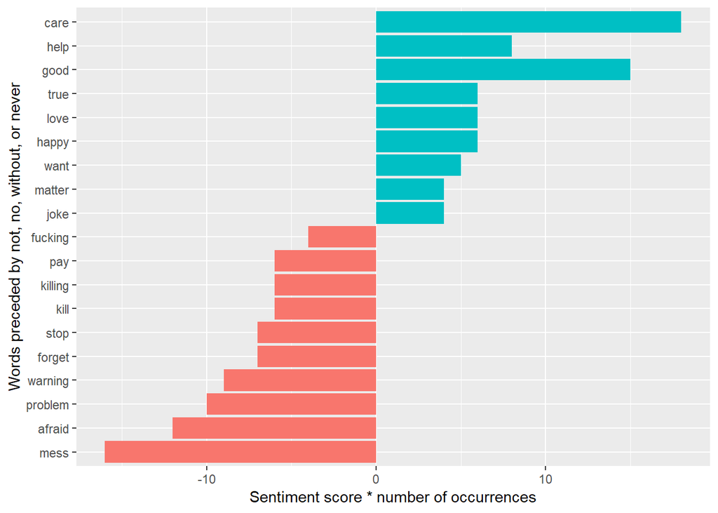

```r
negation_bigrams %>%
  mutate(contribution = n * score) %>%
  arrange(desc(abs(contribution))) %>%
  head(20) %>%
  mutate(word2 = reorder(word2, contribution)) %>%
  ggplot(aes(word2, n * score, fill = n * score > 0)) +
  geom_col(show.legend = FALSE) +
  xlab("Words preceded by not, no, without, or never") +
  ylab("Sentiment score * number of occurrences") +
  coord_flip()
```

## Trigram Analysis

### Cleaning and Tokenization

```r
fb_trigrams <- nlp_fb %>%
  unnest_tokens(trigram, message, token = "ngrams", n = 3)

trigrams_separated <- fb_trigrams %>%
  separate(trigram, c("word1", "word2", "word3"), sep = " ")

trigrams_filtered <- trigrams_separated %>%
  filter(!word1 %in% stop_words$word) %>%
  filter(!word2 %in% stop_words$word) %>%
  filter(!word3 %in% stop_words$word)
```

### Trigrams by month

Trigrams are useful with longer texts, but tweets and Facebook messages don’t produce the best results. I’m including these just incase you’d like to use them in your final report.

```r
trigram_month <- trigrams_filtered %>%
  filter(word1 != word2) %>%
  unite(trigram, word1, word2, word3, sep = " ") %>%
  inner_join(nlp_fb) %>%
  count(trigram, month, sort = TRUE) %>%
  group_by(month) %>%
  slice(seq_len(7)) %>%
  ungroup() %>%
  arrange(month, n) %>%
  mutate(row = row_number())
```

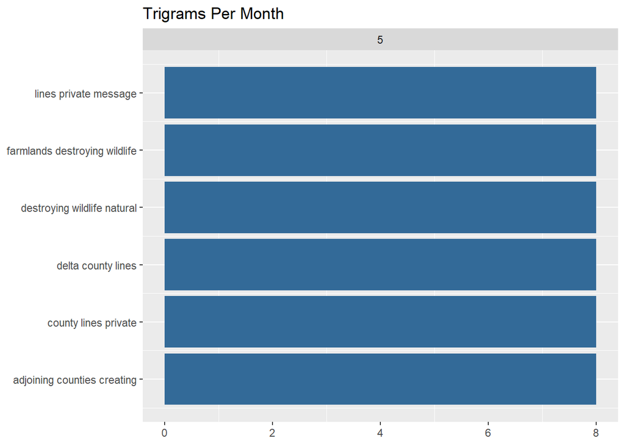

```r
trigram_month %>%
  filter(month == "5", trigram != "text private message") %>%
  ggplot(aes(row, n, fill = month)) +
  geom_col(show.legend = FALSE) +
  facet_wrap(~month, scales = "free_y") +
  xlab(NULL) + ylab(NULL) +
  scale_x_continuous(
    breaks = trigram_month$row,
    labels = trigram_month$trigram) +
  theme(panel.grid.major.x = element_blank()) +
  ggtitle("Trigrams Per Month") +
  coord_flip()
```

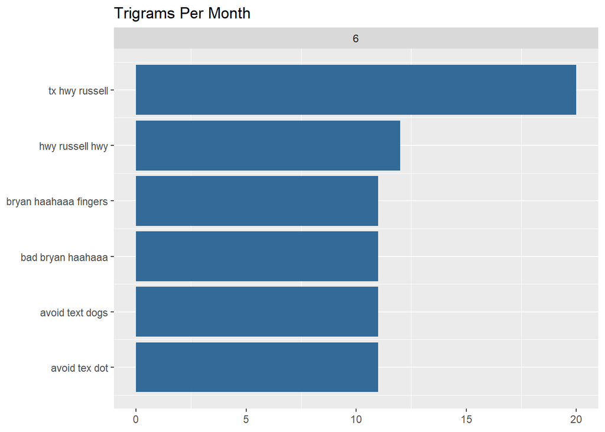

```r
trigram_month %>%
  filter(month == "6", trigram != "text private message") %>%
  ggplot(aes(row, n, fill = month)) +
  geom_col(show.legend = FALSE) +
  facet_wrap(~month, scales = "free_y") +
  xlab(NULL) + ylab(NULL) +
  scale_x_continuous(
    breaks = trigram_month$row,
    labels = trigram_month$trigram) +
  theme(panel.grid.major.x = element_blank()) +
  ggtitle("Trigrams Per Month") +
  coord_flip()
```

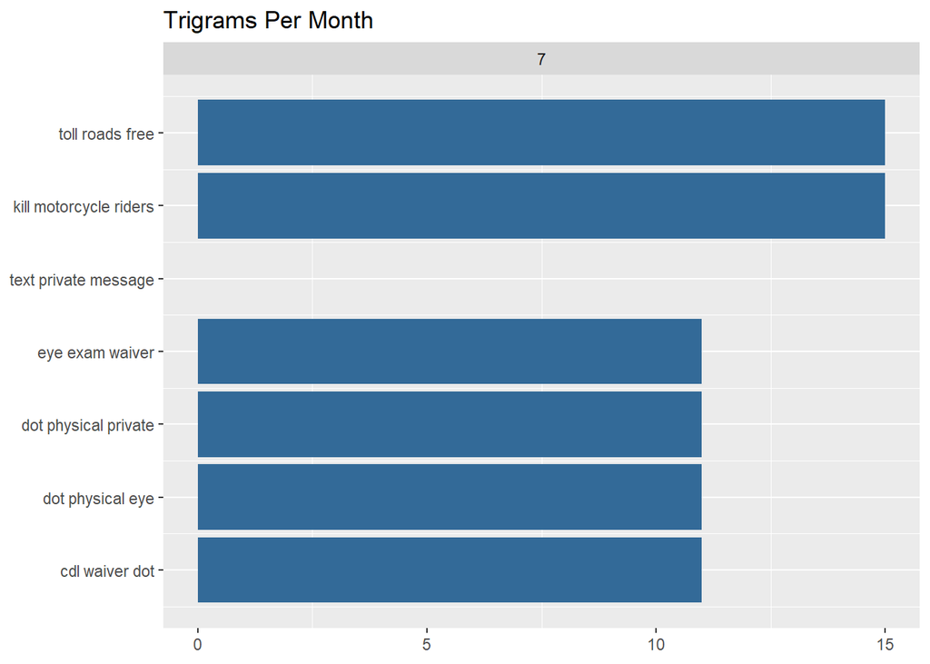

```r
trigram_month %>%
  filter(month == "7", trigram != "text private message") %>%
  ggplot(aes(row, n, fill = month)) +
  geom_col(show.legend = FALSE) +
  facet_wrap(~month, scales = "free_y") +
  xlab(NULL) + ylab(NULL) +
  scale_x_continuous(
    breaks = trigram_month$row,
    labels = trigram_month$trigram) +
  theme(panel.grid.major.x = element_blank()) +
  ggtitle("Trigrams Per Month") +
  coord_flip()
```

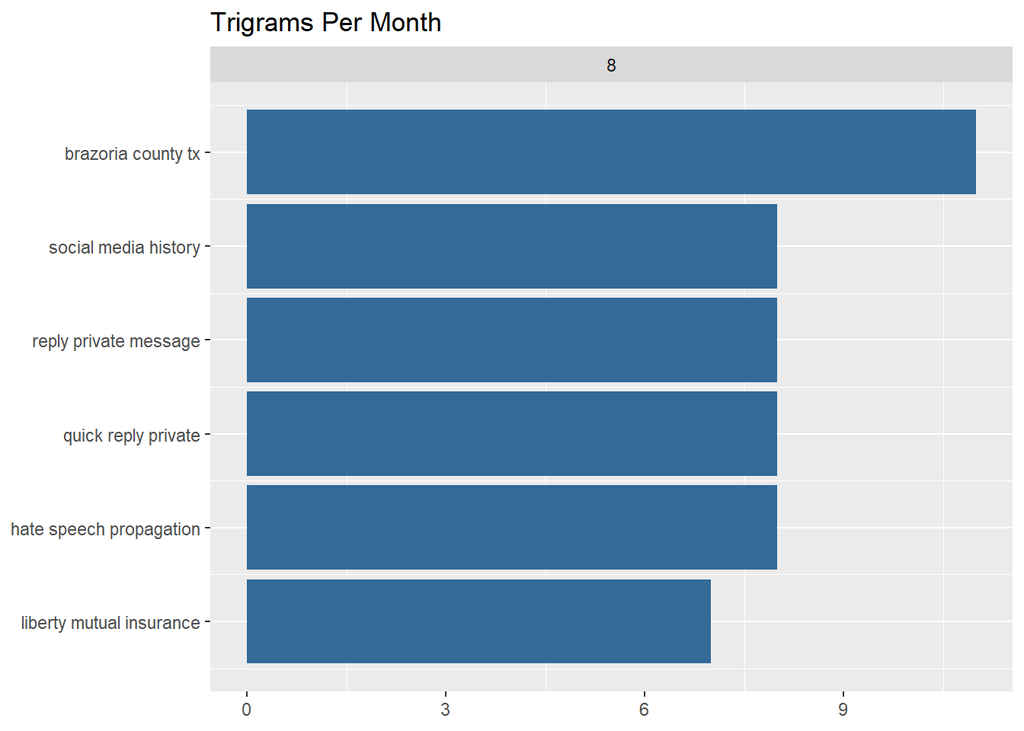

```r
trigram_month %>%
  filter(month == "8", trigram != "text private message") %>%
  ggplot(aes(row, n, fill = month)) +
  geom_col(show.legend = FALSE) +
  facet_wrap(~month, scales = "free_y") +
  xlab(NULL) + ylab(NULL) +
  scale_x_continuous(
    breaks = trigram_month$row,
    labels = trigram_month$trigram) +
  theme(panel.grid.major.x = element_blank()) +
  ggtitle("Trigrams Per Month") +
  coord_flip()
```

```r
write.table(trigram_month, file="txdot_tw_trigrams.csv",sep=",",row.names=F)
write.table(bigram_month, file="txdot_tw_biigrams.csv",sep=",",row.names=F)
```